# Tugas Praktikum Pertemuan 3 - Regresi dengan Peubah Lag

## *Packages*

```r
library(dLagM)
library(dynlm)
library(MLmetrics)
library(lmtest)
library(car)
```

# Data

Data diambil dari ouworldindata dengan peubah x merupakan data populasi Indonesia tahun 1962-2022 dan peubah y merupakan data kadar emisi karbon di Indonesia tahun 1962-2022.

```r
data <- rio::import("https://raw.githubusercontent.com/adindashabrina/dataMPDW/main/Data-Populasi-dan-Emisi-Karbon.csv")
str(data)
```

```
## 'data.frame':    60 obs. of  4 variables:
##  $ t     : int  1 2 3 4 5 6 7 8 9 10 ...
##  $ Yt    : num  0.246 0.237 0.227 0.244 0.226 ...
##  $ Y(t-1): num  NA 0.246 0.237 0.227 0.244 ...
##  $ Xt    : num  0.0934 0.0961 0.0988 0.1014 0.1038 ...
```

```r
data
```

```
##     t        Yt    Y(t-1)         Xt
## 1   1 0.2461275        NA 0.09337585
## 2   2 0.2372082 0.2461275 0.09605142
## 3   3 0.2267469 0.2372082 0.09883376
## 4   4 0.2438587 0.2267469 0.10136513
## 5   5 0.2257117 0.2438587 0.10379276
## 6   6 0.2309418 0.2257117 0.10652640
## 7   7 0.2525465 0.2309418 0.10945001
## 8   8 0.2974805 0.2525465 0.11251764
## 9   9 0.3106125 0.2974805 0.11565750
## 10 10 0.3291610 0.3106125 0.11883370
## 11 11 0.3564182 0.3291610 0.12203984
## 12 12 0.3937011 0.3564182 0.12528852
## 13 13 0.4003785 0.3937011 0.12855505
## 14 14 0.4110298 0.4003785 0.13184385
```

[output cut: 46 more lines]

## Pembagian Data

```r
#SPLIT DATA
train<-data[1:40,]
test<-data[41:60,]
```

```r
#data time series
train.ts<-ts(train)
test.ts<-ts(test)
data.ts<-ts(data)
```

# Model Koyck

Model Koyck didasarkan pada asumsi bahwa semakin jauh jarak lag peubah independen dari periode sekarang maka semakin kecil pengaruh peubah lag terhadap peubah dependen.

Koyck mengusulkan suatu metode untuk menduga model dinamis distributed lag dengan mengasumsikan bahwa semua koefisien $\beta$ mempunyai tanda sama.

Model kyock merupakan jenis paling umum dari model infinite distributed lag dan juga dikenal sebagai geometric lag

$$y_t=a(1-\lambda)+\beta_0X_t+\beta_1Z_t+\lambda Y_{t-1}+V_t$$

dengan
$$V_t=u_t-\lambda
u_{t-1}$$

### Pemodelan

Pemodelan model Koyck dengan `R` dapat menggunakan `dLagM::koyckDlm()` . Fungsi umum dari `koyckDlm` adalah sebagai berikut.

```r
koyckDlm(x , y , intercept)
```

Fungsi `koyckDlm()` akan menerapkan model lag terdistribusi dengan transformasi Koyck satu prediktor. Nilai `x` dan `y` tidak perlu sebagai objek *time series* (`ts`). `intercept` dapat dibuat `TRUE` untuk memasukkan intersep ke dalam model.

```r
#MODEL KOYCK
model.koyck <- koyckDlm(x = train$Xt, y = train$Yt)
summary(model.koyck)
```

```
##
## Call:
## "Y ~ (Intercept) + Y.1 + X.t"
##
## Residuals:
##       Min        1Q    Median        3Q       Max
## -0.181364 -0.026090 -0.002304  0.025187  0.147600
##
## Coefficients:
##             Estimate Std. Error t value Pr(>|t|)
## (Intercept)  -0.2711     0.1032  -2.628  0.01255 *
## Y.1           0.6881     0.1208   5.695 1.78e-06 ***
## X.t           3.2764     1.1515   2.845  0.00728 **
## ---
## Signif. codes:  0 '***' 0.001 '**' 0.01 '*' 0.05 '.' 0.1 ' ' 1
##
## Residual standard error: 0.0628 on 36 degrees of freedom
## Multiple R-Squared: 0.9735,  Adjusted R-squared: 0.9721
## Wald test: 662.2 on 2 and 36 DF,  p-value: < 2.2e-16
##
## Diagnostic tests:
## NULL
##
##                               alpha     beta       phi
## Geometric coefficients:  -0.8692494 3.276406 0.6881261
```

```r
AIC(model.koyck)
```

```
## [1] -100.3319
```

```r
BIC(model.koyck)
```

```
## [1] -93.67769
```

Dari hasil tersebut, didapat bahwa peubah $x_t$ dan $y_{t-1}$ memiliki nilai $P-Value<0.05$. Hal ini menunjukkan bahwa peubah $x_t$ dan $y_{t-1}$ berpengaruh signifikan terhadap $y$. Adapun model keseluruhannya adalah sebagai berikut

$$\hat{Y_t}=-0.2711+3.2764X_t+0.6881Y_{t-1}$$

### Peramalan dan Akurasi

Berikut adalah hasil peramalan y untuk 20 periode kedepan menggunakan model koyck

```r
fore.koyck <- forecast(model = model.koyck, x=test$Xt, h=20)
fore.koyck
```

```
## $forecasts
##  [1] 1.461356 1.471850 1.488502 1.509610 1.534226 1.561357 1.590169 1.620028
##  [9] 1.650683 1.682147 1.714376 1.746887 1.779170 1.810957 1.842098 1.872435
## [17] 1.901847 1.930400 1.957667 1.982797
##
## $call
## forecast.koyckDlm(model = model.koyck, x = test$Xt, h = 20)
##
## attr(,"class")
## [1] "forecast.koyckDlm" "dLagM"
```

```r
mape.koyck <- MAPE(fore.koyck$forecasts, test$Yt) #akurasi data test

#akurasi data training
GoF(model.koyck)
```

```
##              n        MAE          MPE       MAPE      sMAPE      MASE
## model.koyck 39 0.04266313 0.0003653983 0.05629828 0.05652327 0.8258805
##                     MSE     MRAE     GMRAE
## model.koyck 0.003640555 2.032364 0.8127766
```

# Regression with Distributed Lag

Pemodelan model Regression with Distributed Lag dengan `R` dapat menggunakan `dLagM::dlm()` . Fungsi umum dari `dlm` adalah sebagai berikut.

```r
dlm(formula , data , x , y , q , remove )
```

Fungsi `dlm()` akan menerapkan model lag terdistribusi dengan satu atau lebih prediktor. Nilai `x` dan `y` tidak perlu sebagai objek *time series* (`ts`). $q$ adalah integer yang mewakili panjang *lag* yang terbatas.

### Pemodelan (Lag=2)

```r
model.dlm <- dlm(x = train$Xt,y = train$Yt , q = 2)
summary(model.dlm)
```

```
##
## Call:
## lm(formula = model.formula, data = design)
##
## Residuals:
##       Min        1Q    Median        3Q       Max
## -0.195814 -0.028795  0.004855  0.042836  0.158519
##
## Coefficients:
##              Estimate Std. Error t value Pr(>|t|)
## (Intercept)   -0.4607     0.1583  -2.910  0.00633 **
## x.t           32.0482   154.7816   0.207  0.83720
## x.1         -186.9593   307.6174  -0.608  0.54738
## x.2          165.3027   157.8285   1.047  0.30232
## ---
## Signif. codes:  0 '***' 0.001 '**' 0.01 '*' 0.05 '.' 0.1 ' ' 1
##
## Residual standard error: 0.07915 on 34 degrees of freedom
## Multiple R-squared:  0.9586, Adjusted R-squared:  0.9549
## F-statistic: 262.2 on 3 and 34 DF,  p-value: < 2.2e-16
##
## AIC and BIC values for the model:
##         AIC      BIC
## 1 -79.15833 -70.9704
```

```r
AIC(model.dlm)
```

```
## [1] -79.15833
```

```r
BIC(model.dlm)
```

```
## [1] -70.9704
```

Dari hasil diatas, didapat bahwa $P-value$ dari intercept<0.05$. Hal ini menunjukkan bahwa intercept berpengaruh signifikan terhadap $y$. Adapun model keseluruhan yang terbentuk adalah sebagai berikut

$$\hat{Y_t}=-0.4607+32.0482X_t-186.9593X_{t-1}+165.3027X_{t-2}$$

### Peramalan dan Akurasi

Berikut merupakan hasil peramalan $y$ untuk 20 periode kedepan

```r
fore.dlm <- forecast(model = model.dlm, x=test$Xt, h=20)
fore.dlm
```

```
## $forecasts
##  [1] 1.412719 1.447680 1.480981 1.526389 1.550349 1.561023 1.587791 1.621388
##  [9] 1.659479 1.690253 1.712059 1.732674 1.773639 1.823095 1.867495 1.908877
## [17] 1.951490 1.995244 2.026002 2.072968
##
## $call
## forecast.dlm(model = model.dlm, x = test$Xt, h = 20)
##
## attr(,"class")
## [1] "forecast.dlm" "dLagM"
```

```r
mape.dlm <- MAPE(fore.dlm$forecasts, test$Yt)
#akurasi data training
GoF(model.dlm)
```

```
##            n        MAE          MPE       MAPE      sMAPE     MASE         MSE
## model.dlm 38 0.05681213 -0.006232561 0.08998629 0.08932243 1.076575 0.005604704
##               MRAE    GMRAE
## model.dlm 3.338191 1.228975
```

### *Lag* Optimum

```r
#penentuan lag optimum
finiteDLMauto(formula = Yt ~ Xt,
              data = data.frame(train), q.min = 1, q.max = 20,
              model.type = "dlm", error.type = "AIC", trace = TRUE)
```

```
##    q - k    MASE       AIC       BIC   GMRAE    MBRAE R.Adj.Sq    Ljung-Box
## 19    19 0.00000      -Inf      -Inf 0.00000  0.00000      NaN          NaN
## 20    20 0.00000      -Inf      -Inf 0.00000  0.00000      NaN          NaN
## 17    17 0.19764 -84.00666 -61.29678 0.26491  0.29241  0.98056 0.0002468295
## 1      1 1.11285 -82.37309 -75.71884 1.17192  1.04384  0.95573 0.0001732082
## 2      2 1.07658 -79.15833 -70.97040 1.22898 -0.81653  0.95492 0.0003533434
## 18    18 0.18938 -78.67426 -55.76237 0.22001  0.25262  0.96592 0.0001477609
## 3      3 1.02469 -76.44584 -66.78033 1.15799  1.11003  0.95439 0.0008943621
## 4      4 0.96650 -76.35147 -65.26683 1.00834 -0.09290  0.95702 0.0099679065
## 12    12 0.44311 -75.79342 -55.81036 0.61219  0.62611  0.97217 0.2363032112
## 5      5 0.91014 -74.83528 -62.39249 1.02626  0.61059  0.95756 0.0228003972
## 6      6 0.84973 -73.32246 -59.58521 0.95245 15.87705  0.95788 0.0677213971
## 11    11 0.52964 -72.51794 -53.37580 0.56672  0.96516  0.96705 0.6459208959
## 13    13 0.41520 -70.36862 -49.63523 0.44268  0.60106  0.96736 0.1225544606
## 7      7 0.85249 -70.27857 -55.31349 1.11529  1.03842  0.95614 0.0842575628
## 14    14 0.39502 -67.98133 -46.59369 0.47903  1.87246  0.96466 0.0723757005
## 15    15 0.38375 -66.20011 -44.26034 0.47460  0.69445  0.96172 0.0034214215
## 8      8 0.86368 -65.43721 -49.31411 1.21412  0.33227  0.95173 0.1747262256
## 16    16 0.35449 -64.00123 -41.61820 0.41963  0.41262  0.95762 0.0726084306
## 9      9 0.81242 -63.23638 -46.02854 1.13300  0.89529  0.95062 0.3523737533
## 10    10 0.73278 -60.43275 -42.21719 0.82005  1.88186  0.94808 0.9184627744
```

Berdasarkan output tersebut, lag optimum didapatkan ketika lag=17. Selanjutnya dilakukan pemodelan untuk lag=17

```r
#model dlm dengan lag optimum
model.dlm2 <- dlm(x = train$Xt,y = train$Yt , q = 17)
summary(model.dlm2)
```

```
##
## Call:
## lm(formula = model.formula, data = design)
##
## Residuals:
##          1          2          3          4          5          6          7
## -0.0005632  0.0034041 -0.0019066  0.0077268 -0.0221125  0.0028751  0.0240614
##          8          9         10         11         12         13         14
## -0.0258999  0.0210671 -0.0005691 -0.0086815 -0.0074026  0.0152597 -0.0174690
##         15         16         17         18         19         20         21
##  0.0162867 -0.0135370  0.0148733 -0.0076395  0.0030923 -0.0084815  0.0258737
##         22         23
## -0.0376498  0.0173918
##
## Coefficients:
##              Estimate Std. Error t value Pr(>|t|)
## (Intercept)    -2.098      4.170  -0.503   0.6413
## x.t           -63.154    911.888  -0.069   0.9481
## x.1           421.848   2165.264   0.195   0.8550
## x.2          -415.942   3090.429  -0.135   0.8994
## x.3          1329.325   3462.207   0.384   0.7206
## x.4         -4032.940   3339.095  -1.208   0.2937
## x.5          6295.706   3152.815   1.997   0.1165
## x.6         -6502.392   2918.478  -2.228   0.0898 .
## x.7          2920.883   2756.830   1.060   0.3491
## x.8          2221.282   2829.060   0.785   0.4763
## x.9         -4655.388   3099.354  -1.502   0.2075
## x.10         5215.444   3449.439   1.512   0.2051
## x.11        -5870.290   3501.135  -1.677   0.1689
## x.12         6227.603   2882.007   2.161   0.0968 .
## x.13        -3874.550   1924.970  -2.013   0.1144
## x.14         -198.117    846.797  -0.234   0.8265
## x.15         1653.312    602.973   2.742   0.0518 .
## x.16         -997.940    409.088  -2.439   0.0713 .
## x.17          342.647    163.464   2.096   0.1041
## ---
## Signif. codes:  0 '***' 0.001 '**' 0.01 '*' 0.05 '.' 0.1 ' ' 1
##
## Residual standard error: 0.03916 on 4 degrees of freedom
## Multiple R-squared:  0.9965, Adjusted R-squared:  0.9806
## F-statistic: 62.65 on 18 and 4 DF,  p-value: 0.0005517
##
## AIC and BIC values for the model:
##         AIC       BIC
## 1 -84.00666 -61.29678
```

```r
AIC(model.dlm2)
```

```
## [1] -84.00666
```

```r
BIC(model.dlm2)
```

```
## [1] -61.29678
```

Dari hasil tersebut tidak ada peubah yang berpengaruh signifikan terhadap taraf nyata 5% tetapi $x_{t-6}$ , $x_{t-12}$ , $x_{t-15}$, $x_{t-16}$ berpengaruh signifikan terhadap taraf nyata 10%. Adapun keseluruhan model yang terbentuk adalah

$$\hat{Y_t}=-2.098-63.154X_t+...+342.647 X_{t-17}$$

Adapun hasil peramalan 20 periode kedepan menggunakan model tersebut adalah sebagai berikut

```r
#peramalan dan akurasi
fore.dlm2 <- forecast(model = model.dlm2, x=test$Xt, h=20)
mape.dlm2<- MAPE(fore.dlm2$forecasts, test$Yt)
#akurasi data training
GoF(model.dlm2)
```

```
##             n        MAE           MPE       MAPE      sMAPE      MASE
## model.dlm2 23 0.01320975 -0.0002149902 0.01410767 0.01409464 0.1976422
##                     MSE      MRAE     GMRAE
## model.dlm2 0.0002666773 0.9745025 0.2649094
```

Model tersebut merupakan model yang sangat baik dengan nilai MAPE yang kurang dari 10%.

# Model Autoregressive

Peubah dependen dipengaruhi oleh peubah independen pada waktu sekarang, serta dipengaruhi juga oleh peubah dependen itu sendiri pada satu waktu yang lalu maka model tersebut disebut *autoregressive* (Gujarati 2004).

### Pemodelan

Pemodelan Autoregressive dilakukan menggunakan fungsi `dLagM::ardlDlm()` . Fungsi tersebut akan menerapkan *autoregressive* berordo $(p,q)$ dengan satu prediktor. Fungsi umum dari `ardlDlm()` adalah sebagai berikut.

```r
ardlDlm(formula = NULL , data = NULL , x = NULL , y = NULL , p = 1 , q = 1 ,
         remove = NULL )
```

Dengan $p$ adalah integer yang mewakili panjang *lag* yang terbatas dan $q$ adalah integer yang merepresentasikan ordo dari proses *autoregressive*.

```r
#model.ardl <- ardlDlm(x = train$Xt, y = train$Yt, p = 1 , q = 1)
#summary(model.ardl)
#AIC(model.ardl)
#BIC(model.ardl)
```

```r
model.ardl <- ardlDlm(formula = Yt ~ Xt,
                         data = train,p = 1 , q = 1)
summary(model.ardl)
```

```
##
## Time series regression with "ts" data:
## Start = 2, End = 40
##
## Call:
## dynlm(formula = as.formula(model.text), data = data)
##
## Residuals:
##       Min        1Q    Median        3Q       Max
## -0.175661 -0.019623  0.002162  0.015839  0.132589
##
## Coefficients:
##             Estimate Std. Error t value Pr(>|t|)
## (Intercept)  -0.1668     0.1295  -1.288    0.206
## Xt.t        -52.6597    44.0007  -1.197    0.239
## Xt.1         56.7052    44.6207   1.271    0.212
## Yt.1          0.6262     0.1305   4.799 2.94e-05 ***
## ---
## Signif. codes:  0 '***' 0.001 '**' 0.01 '*' 0.05 '.' 0.1 ' ' 1
##
## Residual standard error: 0.06227 on 35 degrees of freedom
## Multiple R-squared:  0.9747, Adjusted R-squared:  0.9725
## F-statistic: 449.5 on 3 and 35 DF,  p-value: < 2.2e-16
```

```r
AIC(model.ardl)
```

```
## [1] -100.0924
```

```r
BIC(model.ardl)
```

```
## [1] -91.77457
```

$$\hat{Y}=-0.1668-52.6597X_t+56.7052X_{t-1}+0.6262Y_{t-1}$$

### Peramalan dan Akurasi

```r
fore.ardl <- forecast(model = model.ardl, x=test$Xt, h=20)
fore.ardl
```

```
## $forecasts
##  [1] 1.476392 1.500268 1.531450 1.559126 1.581261 1.605965 1.634816 1.667165
##  [9] 1.698589 1.726566 1.753528 1.787398 1.828159 1.871348 1.915146 1.959749
## [17] 2.004684 2.046924 2.094805 2.154326
##
## $call
## forecast.ardlDlm(model = model.ardl, x = test$Xt, h = 20)
##
## attr(,"class")
## [1] "forecast.ardlDlm" "dLagM"
```

Data di atas merupakan hasil peramalan untuk 20 periode ke depan menggunakan Model Autoregressive dengan $p=1$ dan $q=1$.

```r
mape.ardl <- MAPE(fore.ardl$forecasts, test$Yt)
mape.ardl
```

```
## [1] 0.06675562
```

```r
#akurasi data training
GoF(model.ardl)
```

```
##             n       MAE          MPE       MAPE     sMAPE      MASE         MSE
## model.ardl 39 0.0405306 -0.004605892 0.05433182 0.0539828 0.7845987 0.003479876
##                MRAE     GMRAE
## model.ardl 2.055801 0.6817497
```

Berdasarkan akurasi di atas, terlihat bahwa nilai MAPE keduanya tidak jauh berbeda. Artinya, model regresi dengan distribusi lag ini tidak `overfitted` atau `underfitted`

### *Lag* Optimum

```r
#penentuan lag optimum
model.ardl.opt <- ardlBoundOrders(data = data.frame(data), ic = "AIC",
                                  formula = Yt ~ Xt )
min_p=c()
for(i in 1:15){
  min_p[i]=min(model.ardl.opt$Stat.table[[i]])
}
q_opt=which(min_p==min(min_p, na.rm = TRUE))
p_opt=which(model.ardl.opt$Stat.table[[q_opt]] ==
              min(model.ardl.opt$Stat.table[[q_opt]], na.rm = TRUE))
data.frame("q_optimum" = q_opt, "p_optimum" = p_opt,
           "AIC"=model.ardl.opt$min.Stat)
```

```
##   q_optimum p_optimum       AIC
## 1         1         1 -123.6981
```

Dari tabel di atas, dapat terlihat bahwa nilai AIC terendah didapat ketika $p=1$ dan $q=1$, yaitu sebesar `-123.6981`. Artinya, model autoregressive optimum didapat ketika $p=1$ dan $q=1$.

Selanjutnya dapat dilakukan pemodelan dengan nilai $p$ dan $q$ optimum seperti inisialisasi di langkah sebelumnya.

# Pemodelan DLM & ARDL dengan Library `dynlm`

Pemodelan regresi dengan peubah *lag* tidak hanya dapat dilakukan dengan fungsi pada *packages* `dLagM` , tetapi terdapat *packages* `dynlm` yang dapat digunakan. Fungsi `dynlm` secara umum adalah sebagai berikut.

```r
dynlm(formula, data, subset, weights, na.action, method = "qr",
  model = TRUE, x = FALSE, y = FALSE, qr = TRUE, singular.ok = TRUE,
  contrasts = NULL, offset, start = NULL, end = NULL, ...)
```

Untuk menentukan `formula` model yang akan digunakan, tersedia fungsi tambahan yang memungkinkan spesifikasi dinamika (melalui `d()` dan `L()`) atau pola linier/siklus dengan mudah (melalui `trend()`, `season()`, dan `harmon()`). Semua fungsi formula baru mengharuskan argumennya berupa objek deret waktu (yaitu, `"ts"` atau `"zoo"`).

```r
#sama dengan model dlm q=1
cons_lm1 <- dynlm(Yt ~ Xt+L(Xt),data = train.ts)
#sama dengan model ardl p=1 q=0
cons_lm2 <- dynlm(Yt ~ Xt+L(Yt),data = train.ts)
#sama dengan ardl p=1 q=1
cons_lm3 <- dynlm(Yt ~ Xt+L(Xt)+L(Yt),data = train.ts)
#sama dengan dlm p=2
cons_lm4 <- dynlm(Yt ~ Xt+L(Xt)+L(Xt,2),data = train.ts)
```

### Ringkasan Model

```r
summary(cons_lm1)
```

```
##
## Time series regression with "ts" data:
## Start = 2, End = 40
##
## Call:
## dynlm(formula = Yt ~ Xt + L(Xt), data = train.ts)
##
## Residuals:
##       Min        1Q    Median        3Q       Max
## -0.193317 -0.034997 -0.001616  0.045411  0.169691
##
## Coefficients:
##              Estimate Std. Error t value Pr(>|t|)
## (Intercept)   -0.4246     0.1496  -2.838  0.00741 **
## Xt          -131.5296    51.8216  -2.538  0.01561 *
## L(Xt)        141.6732    52.0012   2.724  0.00988 **
## ---
## Signif. codes:  0 '***' 0.001 '**' 0.01 '*' 0.05 '.' 0.1 ' ' 1
##
## Residual standard error: 0.07906 on 36 degrees of freedom
## Multiple R-squared:  0.9581, Adjusted R-squared:  0.9557
## F-statistic: 411.2 on 2 and 36 DF,  p-value: < 2.2e-16
```

```r
summary(cons_lm2)
```

```
##
## Time series regression with "ts" data:
## Start = 2, End = 40
##
## Call:
## dynlm(formula = Yt ~ Xt + L(Yt), data = train.ts)
##
## Residuals:
##       Min        1Q    Median        3Q       Max
## -0.182019 -0.025875 -0.002459  0.024856  0.147801
##
## Coefficients:
##             Estimate Std. Error t value Pr(>|t|)
## (Intercept)  -0.2678     0.1031  -2.597  0.01355 *
## Xt            3.2388     1.1511   2.814  0.00789 **
## L(Yt)         0.6920     0.1208   5.729  1.6e-06 ***
## ---
## Signif. codes:  0 '***' 0.001 '**' 0.01 '*' 0.05 '.' 0.1 ' ' 1
##
## Residual standard error: 0.0628 on 36 degrees of freedom
## Multiple R-squared:  0.9735, Adjusted R-squared:  0.9721
## F-statistic: 662.2 on 2 and 36 DF,  p-value: < 2.2e-16
```

```r
summary(cons_lm3)
```

```
##
## Time series regression with "ts" data:
## Start = 2, End = 40
##
## Call:
## dynlm(formula = Yt ~ Xt + L(Xt) + L(Yt), data = train.ts)
##
## Residuals:
##       Min        1Q    Median        3Q       Max
## -0.175661 -0.019623  0.002162  0.015839  0.132589
##
## Coefficients:
##             Estimate Std. Error t value Pr(>|t|)
## (Intercept)  -0.1668     0.1295  -1.288    0.206
## Xt          -52.6597    44.0007  -1.197    0.239
## L(Xt)        56.7052    44.6207   1.271    0.212
## L(Yt)         0.6262     0.1305   4.799 2.94e-05 ***
## ---
## Signif. codes:  0 '***' 0.001 '**' 0.01 '*' 0.05 '.' 0.1 ' ' 1
##
## Residual standard error: 0.06227 on 35 degrees of freedom
## Multiple R-squared:  0.9747, Adjusted R-squared:  0.9725
## F-statistic: 449.5 on 3 and 35 DF,  p-value: < 2.2e-16
```

```r
summary(cons_lm4)
```

```
##
## Time series regression with "ts" data:
## Start = 3, End = 40
##
## Call:
## dynlm(formula = Yt ~ Xt + L(Xt) + L(Xt, 2), data = train.ts)
##
## Residuals:
##       Min        1Q    Median        3Q       Max
## -0.195814 -0.028795  0.004855  0.042836  0.158519
##
## Coefficients:
##              Estimate Std. Error t value Pr(>|t|)
## (Intercept)   -0.4607     0.1583  -2.910  0.00633 **
## Xt            32.0482   154.7816   0.207  0.83720
## L(Xt)       -186.9593   307.6174  -0.608  0.54738
## L(Xt, 2)     165.3027   157.8285   1.047  0.30232
## ---
## Signif. codes:  0 '***' 0.001 '**' 0.01 '*' 0.05 '.' 0.1 ' ' 1
##
## Residual standard error: 0.07915 on 34 degrees of freedom
## Multiple R-squared:  0.9586, Adjusted R-squared:  0.9549
## F-statistic: 262.2 on 3 and 34 DF,  p-value: < 2.2e-16
```

### SSE

```r
deviance(cons_lm1)
```

```
## [1] 0.2250182
```

```r
deviance(cons_lm2)
```

```
## [1] 0.1419774
```

```r
deviance(cons_lm3)
```

```
## [1] 0.1357152
```

```r
deviance(cons_lm4)
```

```
## [1] 0.2129788
```

### Uji Diagnostik

```r
#uji model
if(require("lmtest")) encomptest(cons_lm1, cons_lm2)
```

```
## Encompassing test
##
## Model 1: Yt ~ Xt + L(Xt)
## Model 2: Yt ~ Xt + L(Yt)
## Model E: Yt ~ Xt + L(Xt) + L(Yt)
##           Res.Df Df      F   Pr(>F)
## M1 vs. ME     35 -1 23.031 2.94e-05 ***
## M2 vs. ME     35 -1  1.615   0.2122
## ---
## Signif. codes:  0 '***' 0.001 '**' 0.01 '*' 0.05 '.' 0.1 ' ' 1
```

#### Autokorelasi

```r
#durbin watson
dwtest(cons_lm1)
```

```
##
##  Durbin-Watson test
##
## data:  cons_lm1
## DW = 0.78629, p-value = 1.555e-06
## alternative hypothesis: true autocorrelation is greater than 0
```

```r
dwtest(cons_lm2)
```

```
##
##  Durbin-Watson test
##
## data:  cons_lm2
## DW = 2.3662, p-value = 0.8069
## alternative hypothesis: true autocorrelation is greater than 0
```

```r
dwtest(cons_lm3)
```

```
##
##  Durbin-Watson test
##
## data:  cons_lm3
## DW = 2.31, p-value = 0.6979
## alternative hypothesis: true autocorrelation is greater than 0
```

```r
dwtest(cons_lm4)
```

```
##
##  Durbin-Watson test
##
## data:  cons_lm4
## DW = 0.84146, p-value = 5.139e-06
## alternative hypothesis: true autocorrelation is greater than 0
```

#### Heterogenitas

```r
bptest(cons_lm1)
```

```
##
##  studentized Breusch-Pagan test
##
## data:  cons_lm1
## BP = 4.6087, df = 2, p-value = 0.09983
```

```r
bptest(cons_lm2)
```

```
##
##  studentized Breusch-Pagan test
##
## data:  cons_lm2
## BP = 14.629, df = 2, p-value = 0.0006659
```

```r
bptest(cons_lm3)
```

```
##
##  studentized Breusch-Pagan test
##
## data:  cons_lm3
## BP = 13.942, df = 3, p-value = 0.002985
```

```r
bptest(cons_lm4)
```

```
##
##  studentized Breusch-Pagan test
##
## data:  cons_lm4
## BP = 3.8094, df = 3, p-value = 0.2828
```

#### Kenormalan

```r
shapiro.test(residuals(cons_lm1))
```

```
##
##  Shapiro-Wilk normality test
##
## data:  residuals(cons_lm1)
## W = 0.98083, p-value = 0.7337
```

```r
shapiro.test(residuals(cons_lm2))
```

```
##
##  Shapiro-Wilk normality test
##
## data:  residuals(cons_lm2)
## W = 0.95759, p-value = 0.1481
```

```r
shapiro.test(residuals(cons_lm3))
```

```
##
##  Shapiro-Wilk normality test
##
## data:  residuals(cons_lm3)
## W = 0.94689, p-value = 0.06457
```

```r
shapiro.test(residuals(cons_lm4))
```

```
##
##  Shapiro-Wilk normality test
##
## data:  residuals(cons_lm4)
## W = 0.98095, p-value = 0.7509
```

# Kesimpulan

## Perbandingan Model

```r
akurasi <- matrix(c(mape.koyck, mape.dlm, mape.dlm2, mape.ardl))
row.names(akurasi)<- c("Koyck","DLM 1","DLM 2","Autoregressive")
colnames(akurasi) <- c("MAPE")
akurasi
```

```
##                      MAPE
## Koyck          0.08834523
## DLM 1          0.08035993
## DLM 2          0.09873475
## Autoregressive 0.06675562
```

Berdasarkan nilai MAPE, model paling optimum didapat pada Model Autoregressive karena memiliki nilai MAPE yang terkecil.

### Plot

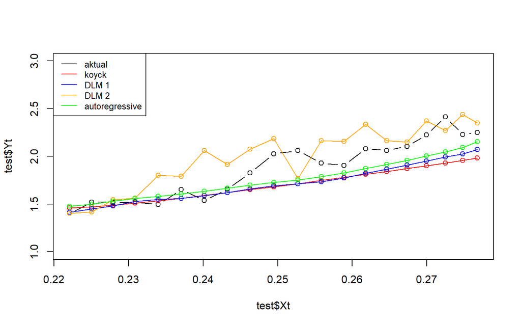

```r
par(mfrow=c(1,1))
plot(test$Xt, test$Yt, type="b", col="black", ylim=c(1,3))
points(test$Xt, fore.koyck$forecasts,col="red")
lines(test$Xt, fore.koyck$forecasts,col="red")
points(test$Xt, fore.dlm$forecasts,col="blue")
lines(test$Xt, fore.dlm$forecasts,col="blue")
points(test$Xt, fore.dlm2$forecasts,col="orange")
lines(test$Xt, fore.dlm2$forecasts,col="orange")
points(test$Xt, fore.ardl$forecasts,col="green")
lines(test$Xt, fore.ardl$forecasts,col="green")
legend("topleft",c("aktual", "koyck","DLM 1","DLM 2", "autoregressive"), lty=1, col=c("black","red","blue","orange","green"), cex=0.8)
```

Berdasarkan plot tersebut, terlihat bahwa plot yang paling mendekati data aktualnya adalah Model Autoregressive, sehingga dapat disimpulkan model terbaik dalam hal ini adalah model regresi Autoregressive

[figure not shown]

```r
par(mfrow=c(1,1))
plot(test$Xt, test$Yt, type="b", col="black", ylim=c(1,3),main="Aktual vs Autoregressive")
par(mfrow=c(1,1))
plot(test$Xt, test$Yt, type="b", col="black", ylim=c(1,3),main="Aktual vs Autoregressive")
points(test$Xt, fore.koyck$forecasts,col="red")
lines(test$Xt, fore.koyck$forecasts,col="red")
```